# (1987-Flight Delay Analysis)

## by (Mohamed Hamdy)

## Preliminary Wrangling

> This data set includes arrival and departure information about some commercial flights within USA, Data includes around 29 feature in each year from 1987 to 2008. However, we wil start only with 1987 dataset.

## Univariate Exploration

> In this section, we will investigate distributions of individual variables. to check unusual points or outliers

##### Checking the frequency of delay departure time (most common delay time durations)

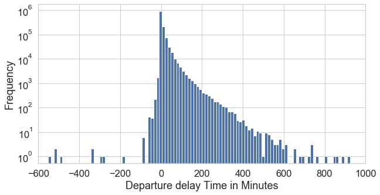

```python
sb.set(rc={'figure.figsize':(11,8)}, font_scale=1.5, style='whitegrid')
plt.figure(figsize=(10,5))
plt.hist(df['DepDelay'],bins=200)
plt.xlim((-600,1000))
plt.yscale('log')
plt.xlabel('Departure delay Time in Minutes')
plt.ylabel('Frequency');
plt.title('Departure Delay Time Frequency',fontsize=20, fontweight=0, color='purple', style='italic');
```

##### Checking the frequency of delay arrival time (most common delay time durations)

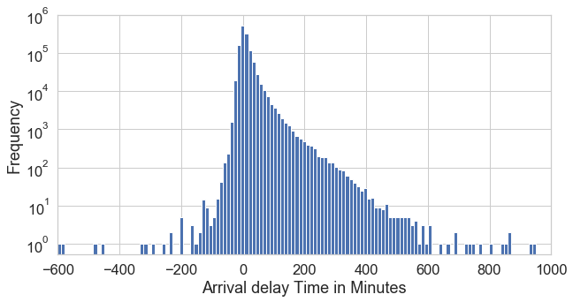

```python
plt.figure(figsize=(10,5))
plt.hist(df['ArrDelay'],bins=200)
plt.xlim((-600,1000))
plt.yscale('log')
plt.xlabel('Arrival delay Time in Minutes')
plt.ylabel('Frequency')
plt.title('Arrival Delay Time Frequency',fontsize=20, fontweight=0, color='purple', style='italic');
```

##### As we can see from the above plots that most of the delayed time values fall between -100 and 100 min in departure and arrival

##### Means that Early and late departure times fall between -200 and 200 min

#### Invistigating the most common origin airports with the highest rate of flights

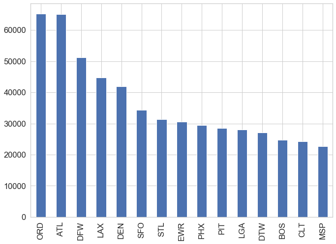

```python
# most common 15 origin airports in the dataset
df2['Origin'].value_counts()[:15].plot(kind='bar');
plt.title('Origin Airports Frequency',fontsize=20, fontweight=0, color='purple', style='italic');
plt.xlabel('Origin Airports')
plt.ylabel('Frequency')
```

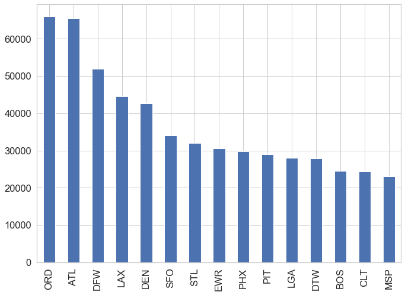

```python
# most common 15 destination airports in the dataset
df2['Dest'].value_counts()[:15].plot(kind='bar');
plt.title('Destination Airports Frequency',fontsize=20, fontweight=0, color='purple', style='italic');
plt.xlabel('Destination Airports')
plt.ylabel('Frequency')
```

```python
# explore sitances above 4000 mile
df2[df2['Distance']>4000]
```

|  | Month | DayOfWeek | DepTime | CRSDepTime | ArrTime | DepDelay | CRSArrTime | ArrDelay | ActualElapsedTime | CRSElapsedTime | Distance | UniqueCarrier | Cancelled | Diverted | Origin | Dest |
| --- | --- | --- | --- | --- | --- | --- | --- | --- | --- | --- | --- | --- | --- | --- | --- | --- |
| 13533 | Oct | Thur | 1222.0 | 1210 | 1538.0 | 12.0 | 1540 | -2.0 | 496.0 | 510 | 4129.0 | TW | 0 | 0 | STL | HNL |
| 13534 | Oct | Fri | 1211.0 | 1210 | 1516.0 | 1.0 | 1540 | -24.0 | 485.0 | 510 | 4129.0 | TW | 0 | 0 | STL | HNL |
| 13535 | Oct | Sat | 1214.0 | 1210 | 1505.0 | 4.0 | 1540 | -35.0 | 471.0 | 510 | 4129.0 | TW | 0 | 0 | STL | HNL |
| 13536 | Oct | Sun | 1230.0 | 1210 | 1528.0 | 20.0 | 1540 | -12.0 | 478.0 | 510 | 4129.0 | TW | 0 | 0 | STL | HNL |
| 13537 | Oct | Mon | 1213.0 | 1210 | 1524.0 | 3.0 | 1540 | -16.0 | 491.0 | 510 | 4129.0 | TW | 0 | 0 | STL | HNL |
| ... | ... | ... | ... | ... | ... | ... | ... | ... | ... | ... | ... | ... | ... | ... | ... | ... |
| 1296223 | Dec | Wed | 817.0 | 820 | 2209.0 | -3.0 | 2235 | -26.0 | 532.0 | 555 | 4962.0 | CO | 0 | 0 | HNL | EWR |
| 1296224 | Dec | Thur | 823.0 | 820 | 2220.0 | 3.0 | 2235 | -15.0 | 537.0 | 555 | 4962.0 | CO | 0 | 0 | HNL | EWR |
| 1296225 | Dec | Sat | 819.0 | 820 | 2208.0 | -1.0 | 2235 | -27.0 | 529.0 | 555 | 4962.0 | CO | 0 | 0 | HNL | EWR |
| 1296226 | Dec | Sun | 818.0 | 820 | 2156.0 | -2.0 | 2235 | -39.0 | 518.0 | 555 | 4962.0 | CO | 0 | 0 | HNL | EWR |
| 1296227 | Dec | Wed | 822.0 | 820 | 2158.0 | 2.0 | 2235 | -37.0 | 516.0 | 555 | 4962.0 | CO | 0 | 0 | HNL | EWR |

1015 rows × 16 columns

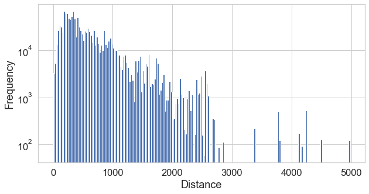

```python
# plotting ditance histogram showing the most common distances has been done by flights
plt.figure(figsize=(10,5))
plt.hist(df['Distance'],bins=200)

plt.yscale('log')

plt.xlabel('Distance')
plt.ylabel('Frequency');
plt.title('Distance Frequency',fontsize=20, fontweight=0, color='purple', style='italic');
```

```python
# Converting month column to string
df2["Month"] = df2["Month"].apply(str)
# Replace 10,11,12 month by the month name instead
df2["Month"] = df2["Month"].apply(lambda x: x.replace('10', "Oct"))
df2["Month"] = df2["Month"].apply(lambda x: x.replace('11', "Nov"))
df2["Month"] = df2["Month"].apply(lambda x: x.replace('12', "Dec"))
```

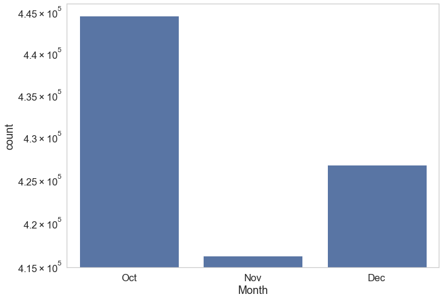

```python
# Flight frequency in each provided month
base_color=sb.color_palette()[0]
sb.countplot(data=df2,x='Month',color=base_color)
plt.yscale('log')
plt.title('Month Frequency',fontsize=20, fontweight=0, color='purple', style='italic');
```

##### From this countplot we can say that October has the most flight rate rather November and December

```python
df["Cancelled"] = df["Cancelled"].apply(str)
```

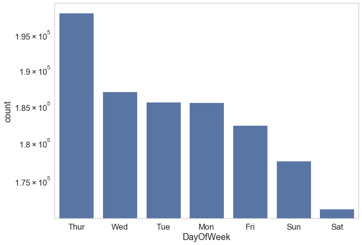

```python
# flight frequency in each provided day of week

sb.countplot(data=df2,x='DayOfWeek',color=base_color,order=ordered)
plt.yscale('log')
plt.title('Day of week Frequency',fontsize=20, fontweight=0, color='purple', style='italic');
```

##### As we can see that Thursaday is the day that has the highest flight frequency in the dataset in all months(OCT,NOV,DEC)

**Plotting unique carrier countplot to figureout what i sthe most used carrier during those flights**

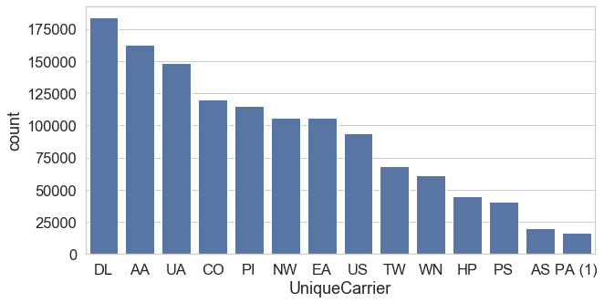

```python
# Creating a unique carrier order variable to plot the counplot chart
carrier_order = df2['UniqueCarrier'].value_counts().index
# plotting unique carrie frequency chart
plt.figure(figsize=(10,5))
sb.countplot(data = df2,x='UniqueCarrier',order=carrier_order,color=base_color);
plt.title('Unique Carrier Frequency',fontsize=20, fontweight=0, color='purple', style='italic');
```

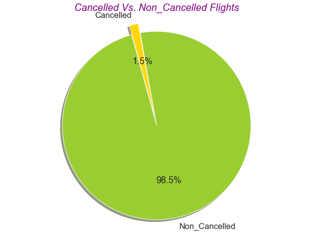

```python
# showing the percentage of canclled to non_cancelled flights
labels = 'Cancelled', 'Non_Cancelled'
sizes = [cancelled_prop ,Non_cancelled_prop]
colors = ['gold', 'yellowgreen']
explode = (0.1, 0)  # explode 1st slice

# Plot pie chart
plt.pie(sizes, explode=explode, labels=labels, colors=colors,
autopct='%1.1f%%', shadow=True, startangle=100)
plt.title('Cancelled Vs. Non_Cancelled Flights',fontsize=20, fontweight=0, color='purple', style='italic');

plt.axis('equal')
plt.show()
```

##### From the pie chart we can see that the cancelled flights over the three months in 1987 is about 1.5 % from the whole flights

# Bivariate Exploration

> In this section, investigate relationships between pairs of variables in the data. Make sure the variables that you cover here have been introduced in some fashion in the previous section (univariate exploration).

**Invistigating the month which has the most cancelation flights**

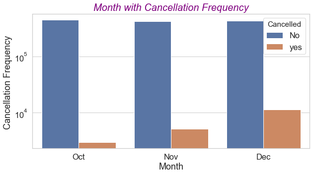

```python
# plotting count plot for month by cancelation frequency
plt.figure(figsize=(10,5))
sb.countplot(data=df,x='Month',hue='Cancelled')
plt.yscale('log')
plt.ylabel('Cancellation Frequency ');
plt.title('Month with Cancellation Frequency',fontsize=20, fontweight=0, color='purple', style='italic')
```

##### Obviuosly as we can see that December has the highest cancelation rate according to flights in October and November

**Exploring the days which have the most delayed time in departure**

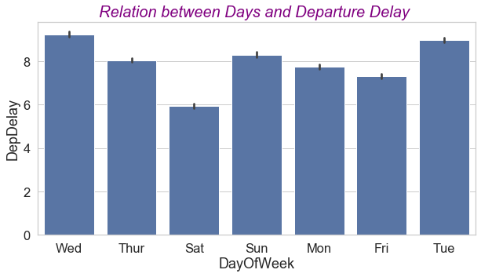

```python
# Relation between Day of week and Departure delay
plt.figure(figsize=(10,5))
base_color = sb.color_palette()[0]
sb.barplot(data=df2,x='DayOfWeek',y='DepDelay',color=base_color);
plt.title('Relation between Days and Departure Delay ',fontsize=20, fontweight=0, color='purple', style='italic');
```

##### As we can see from this bar chart that Wednesday and Tueday are the most days accompanied by late departure flights

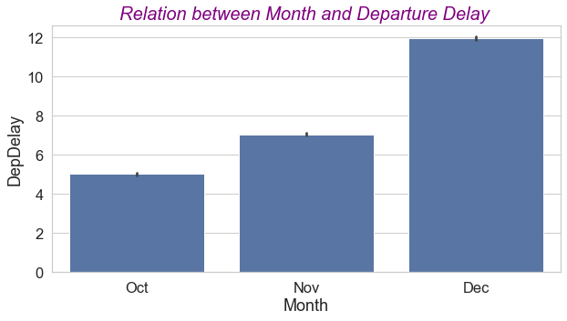

```python
plt.figure(figsize=(10,5))
base_color = sb.color_palette()[0]
sb.barplot(data=df2,x='Month',y='DepDelay',color=base_color);
plt.title('Relation between Month and Departure Delay ',fontsize=20, fontweight=0, color='purple', style='italic');
```

**Plotting a scatter plot between distance made and arrival time delay see if there is a direct relationship**

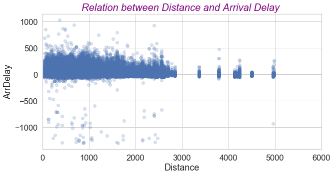

```python
# Relation between Distnace and Arrival delay
plt.figure(figsize=(10,5))
base_color = sb.color_palette()[0]
sb.regplot(data=df2,x='Distance',y='ArrDelay',color=base_color,fit_reg=False,x_jitter=.8,scatter_kws={'alpha':0.2});
plt.xlim((0,6000));
plt.title('Relation between Distance and Arrival Delay ',fontsize=20, fontweight=0, color='purple', style='italic');
```

*Plotting a countplot to figure out which days has the most cancelation rate*

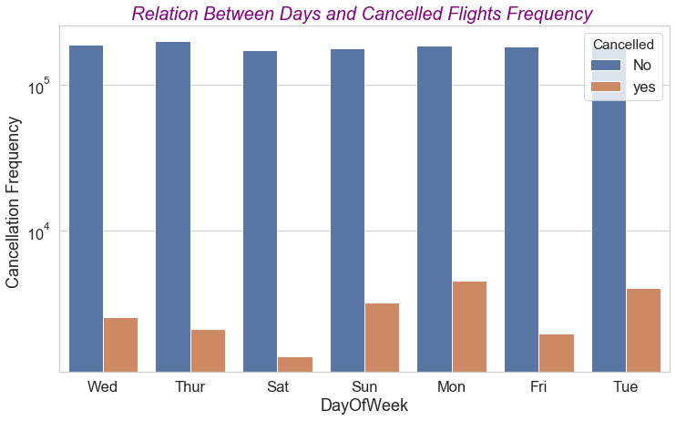

```python
plt.figure(figsize=(12,7))
sb.countplot(data=df,x='DayOfWeek',hue='Cancelled')
plt.yscale('log')
plt.ylabel('Cancellation Frequency ');
plt.title('Relation Between Days and Cancelled Flights Frequency ',fontsize=20, fontweight=0, color='purple', style='italic');
```

##### Monday, Tuesday, and Sundays are the most days with cancelled flights

**Plotting bar chart to invistigate which flight carrier accompanied with the highest amount of time of arrival delay**

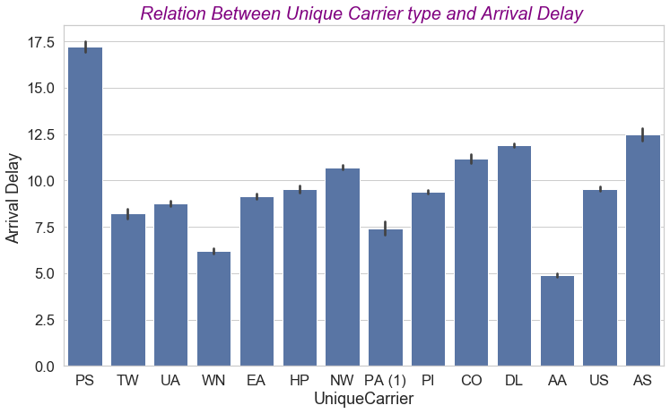

```python
# Plotting a bar chart
plt.figure(figsize=(12,7))
sb.barplot(data=df2,x='UniqueCarrier',y='ArrDelay',color=base_color)

plt.ylabel('Arrival Delay ');
plt.title('Relation Between Unique Carrier type and Arrival Delay ',fontsize=20, fontweight=0, color='purple', style='italic');
```

##### PS and AS are the most carrier types involoved with the highest amount of delay in arrival

**Plotting box plot to see which carrier type involoved with the highest delayed number of flights**

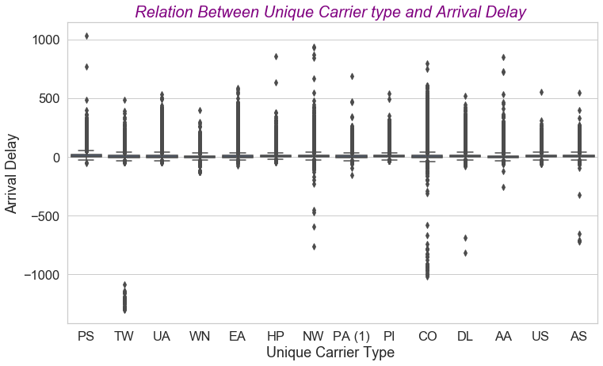

```python
# plotting box plot between carrier and Arrival delay
plt.figure(figsize=(12,7))
sb.boxplot(data=df2,x='UniqueCarrier',y='ArrDelay',color=base_color)
plt.xlabel('Unique Carrier Type ')
plt.ylabel('Arrival Delay');
plt.title('Relation Between Unique Carrier type and Arrival Delay ',fontsize=20, fontweight=0, color='purple', style='italic');
```

###### We can see that PS carrier is the most unique carrier accompanied with highest amount of time delay in arrival, followed by AS unique Carriers , and CO is the most carruer accompanied with early arrival flights

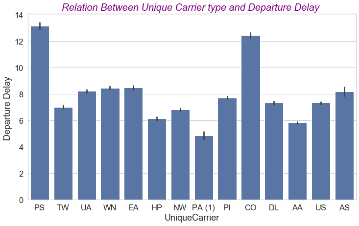

```python
# Plotting a bar chart
plt.figure(figsize=(12,7))
sb.barplot(data=df2,x='UniqueCarrier',y='DepDelay',color=base_color)

plt.ylabel('Departure Delay ');
plt.title('Relation Between Unique Carrier type and Departure Delay ',fontsize=20, fontweight=0, color='purple', style='italic');
```

##### PS and CO carrier types are the most types involoved with the highest delayed in departure flights times (amount)

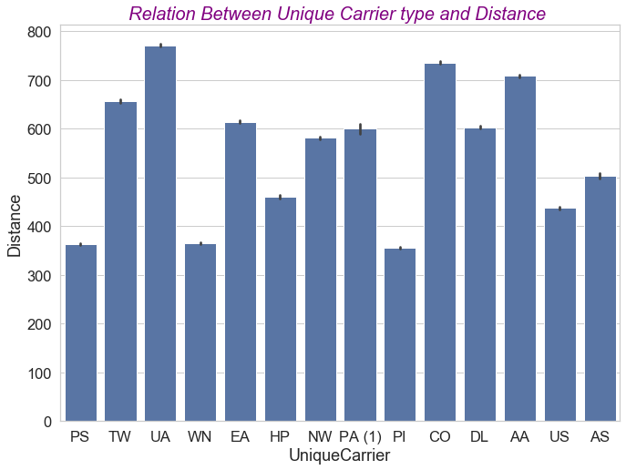

```python
# Plotting Distance and Carrier types
sb.barplot(data =df, x = 'UniqueCarrier', y = 'Distance',color=base_color);
plt.title('Relation Between Unique Carrier type and Distance ',fontsize=20, fontweight=0, color='purple', style='italic');
```

##### We can see that UA, CO, AA are the most carrier types involved with the long distance flights

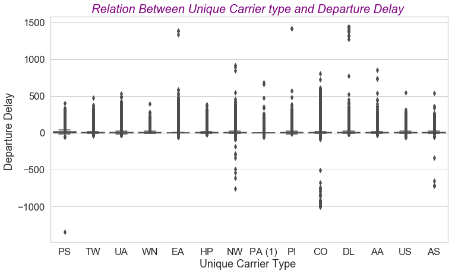

```python
# plotting box plot between carrier and departure delay
plt.figure(figsize=(12,7))
sb.boxplot(data=df2,x='UniqueCarrier',y='DepDelay',color=base_color)
plt.xlabel('Unique Carrier Type ')
plt.ylabel('Departure Delay ');
plt.title('Relation Between Unique Carrier type and Departure Delay ',fontsize=20, fontweight=0, color='purple', style='italic');
```

**Plotting carrier type and cancelled flights together**

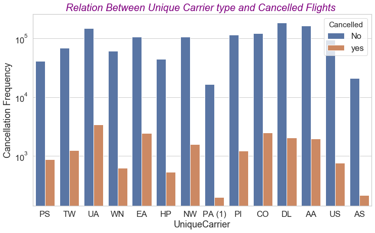

```python
# Plotting Unique carrier versus cancellation frequency
plt.figure(figsize=(12,7))
sb.countplot(data=df,x='UniqueCarrier',hue='Cancelled')
plt.yscale('log')
plt.ylabel('Cancellation Frequency');
plt.title('Relation Between Unique Carrier type and Cancelled Flights ',fontsize=20, fontweight=0, color='purple', style='italic');
```

##### We can see that UA,EA,CO, and DL are the most unique carrier types with cancelled flights compared to the Non-cancelled flights

**Investigation the percentage of diverted planes**

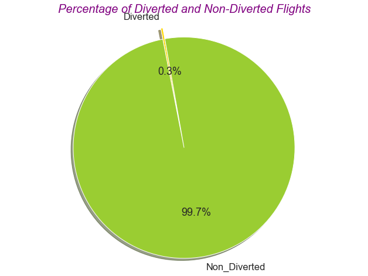

```python
# Figuring the percentage of diverted flights
labels = 'Diverted', 'Non_Diverted'
sizes = [diverted_prop ,nondivert_prop]
colors = ['gold', 'yellowgreen']
explode = (0.1, 0)  # explode 1st slice

# Plot pie chart
plt.pie(sizes, explode=explode, labels=labels, colors=colors,
autopct='%1.1f%%', shadow=True, startangle=100)
plt.title('Percentage of Diverted and Non-Diverted Flights',fontsize=20, fontweight=0, color='purple', style='italic');

plt.axis('equal')
plt.show()
```

##### The percentage of divereted flights are too small compared to the directed flights 0.3%

**Plotting a scatter plot for distance and actual elapsed time for the flights**

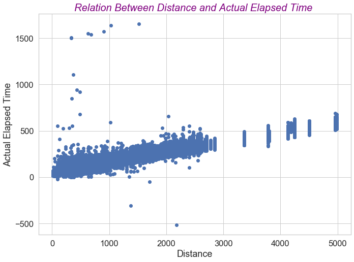

```python
# plotting scatter plot between distance and actual elapsed time
plt.scatter(data=df2,x='Distance',y='ActualElapsedTime');
plt.xlabel('Distance')
plt.ylabel('Actual Elapsed Time')
plt.title('Relation Between Distance and Actual Elapsed Time ',fontsize=20, fontweight=0, color='purple', style='italic');
```

##### Obviuosly we can see the strong relationship between the distance and the elapsed time for the flight, The longer the distance the more duration of the flight

**Investigating which day of weeks are accompanied with the most delay arrivals and early arrivals**

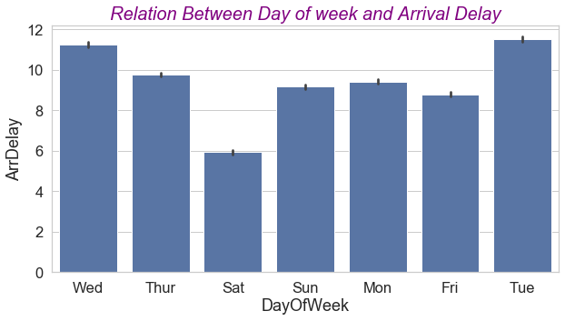

```python
# investigating which day of weeks are accompanied with the most delay arrivals and early arrivals
plt.figure(figsize=(10,5))
sb.barplot(data=df2,x='DayOfWeek',y='ArrDelay',color=base_color);
plt.title('Relation Between Day of week and Arrival Delay',fontsize=20, fontweight=0, color='purple', style='italic');
```

##### Wednesday and Tuesday are the most days accompanied with the highest amount of arrival delay time

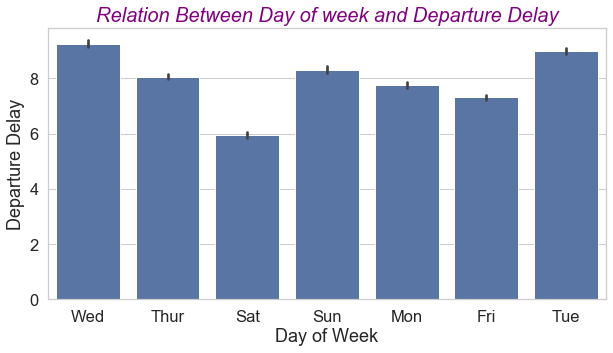

```python
plt.figure(figsize=(10,5))
sb.barplot(data=df2,x='DayOfWeek',y='DepDelay',color=base_color);
#plt.ylim((-1500,1500));
plt.ylabel('Departure Delay')
plt.xlabel('Day of Week');
plt.title('Relation Between Day of week and Departure Delay',fontsize=20, fontweight=0, color='purple', style='italic');
```

##### Wednesday and Tuesday are the most days accompanied with the highest amount of departure delay time

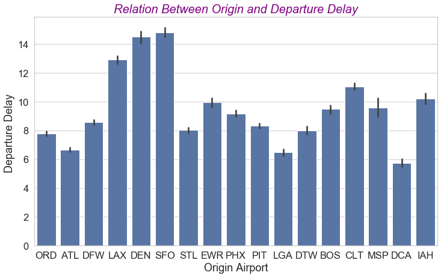

```python
# Plotting a bar plot between origin and departure delay
plt.figure(figsize=(12,7))
sb.barplot(data=df2,x='Origin',y='DepDelay',color=base_color,order=origin_value)
sb.set(rc={'figure.figsize':(11,8)}, font_scale=1.5, style='whitegrid')


plt.ylabel('Departure Delay ')
plt.xlabel('Origin Airport');
plt.title('Relation Between Origin and Departure Delay',fontsize=20, fontweight=0, color='purple', style='italic');
```

##### SFO, DEN, LAX are the most origing airports with the highest amount of departure delay time

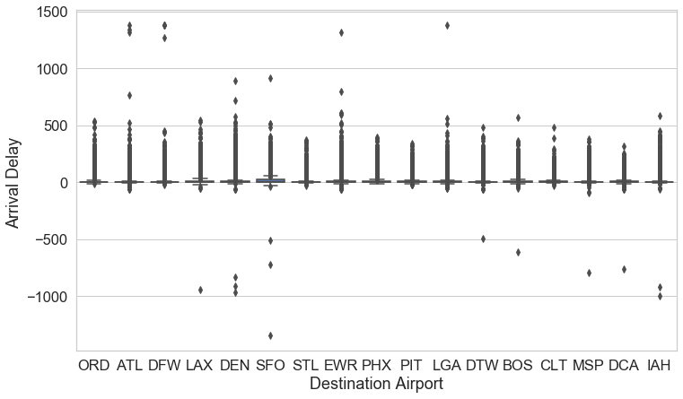

```python
plt.figure(figsize=(12,7))
sb.boxplot(data=df2,x='Dest',y='DepDelay',color=base_color,order=origin_value)
sb.set(rc={'figure.figsize':(11,8)}, font_scale=1.5, style='whitegrid')


plt.ylabel('Arrival Delay ')
plt.xlabel('Destination Airport');
plt.title('Relation Between Destination and Arrival Delay',fontsize=20, fontweight=0, color='purple', style='italic');
```

**Investigating the relation between elapsed time and the destination airport**

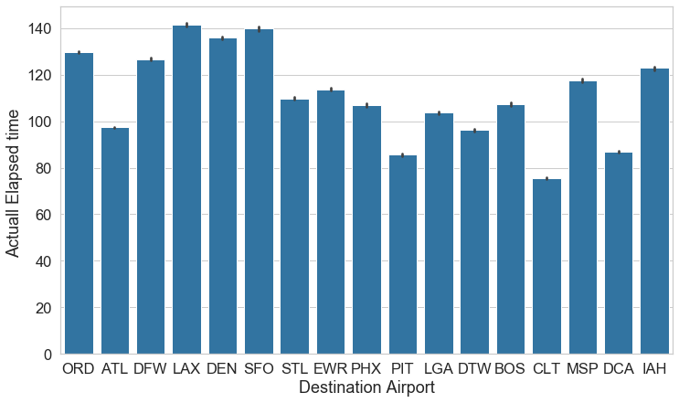

```python
# Distnintaion with actual elapsed time
plt.figure(figsize=(12,7))
sb.barplot(data=df2,x='Dest',y='ActualElapsedTime',color=base_color,order=origin_value)
#sb.set(rc={'figure.figsize':(11,8)}, font_scale=1.5, style='whitegrid')

plt.ylabel('Actuall Elapsed time ')
plt.xlabel('Destination Airport');
plt.title('Relation Between Destination and Actual Elapsed Time',fontsize=20, fontweight=0, color='purple', style='italic');
```

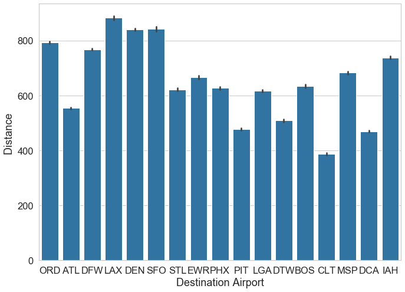

```python
sb.barplot(data=df2,x='Dest',y='Distance',color=base_color,order=origin_value)
plt.ylabel('Distance ')
plt.xlabel('Destination Airport');
plt.title('Relation Between Destination and Distance',fontsize=20, fontweight=0, color='purple', style='italic');
```

##### LAX destination airport seems to be the farest airport from any of origin airports, beacuse it has the highest distance

**Creating a plot to figure out the day of week most involved with the departure delay flights regardless the amount of delay**

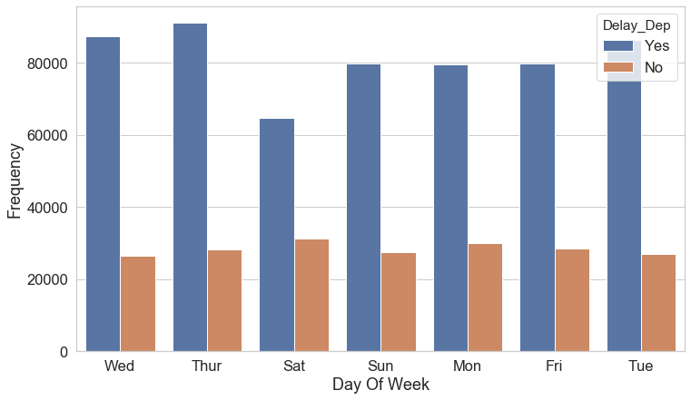

```python
plt.figure(figsize=(12,7))
sb.countplot(data=df2,x='DayOfWeek',hue='Delay_Dep')
plt.ylabel('Frequency')
plt.xlabel('Day Of Week');
plt.title('Day of week Vs. Departure Delay',fontsize=20, fontweight=0, color='purple', style='italic');
```

##### From this plot we can see that Thursday, Wednesday, and Tuesday are the most days involoved with flight departure delay

**Creating a plot to figure out the day of week most involved with the arrival delayed flights regardless the amount of delay**

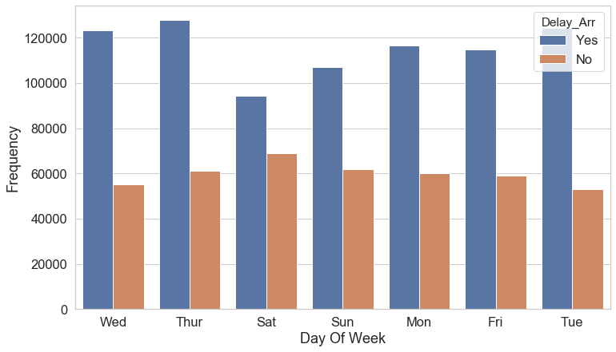

```python
plt.figure(figsize=(12,7))
sb.countplot(data=df2,x='DayOfWeek',hue='Delay_Arr')
plt.ylabel('Frequency')
plt.xlabel('Day Of Week');
plt.title('Day of week Vs. Arrival Delay',fontsize=20, fontweight=0, color='purple', style='italic');
```

##### From this plot we can see that Wednesday, Thursday, and Tuesday are the most days involoved with flight arrival delay

**we are going to discover the relation between month, arrival, and departure delays**

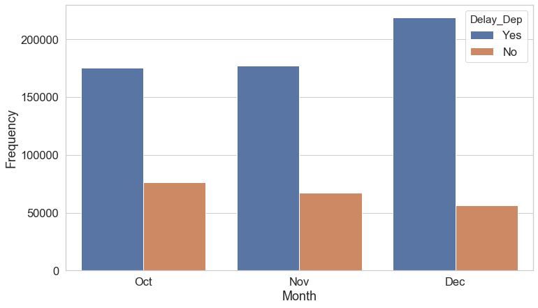

```python
plt.figure(figsize=(12,7))
sb.countplot(data=df2,x='Month',hue='Delay_Dep')
plt.ylabel('Frequency')
plt.xlabel('Month');
plt.title('Month Vs. Departure Delay',fontsize=20, fontweight=0, color='purple', style='italic');
```

##### Obviously December is the most month involved with delayed departure flights

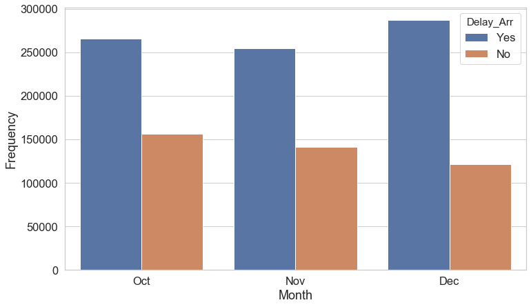

```python
plt.figure(figsize=(12,7))
sb.countplot(data=df2,x='Month',hue='Delay_Arr')
plt.ylabel('Frequency')
plt.xlabel('Month');
plt.title('Month Vs. Arrival Delay',fontsize=20, fontweight=0, color='purple', style='italic');
```